USDA inflammation - summary stats for carotenoids, cytokines, and immune cells

Maria Sholola March 2022 and so on

# Introduction

Statistical analysis of plasma carotenoids, plasma cytokines and immune cells from randomized cross-over USDA inflammation clinical trial. Subjects consumed both low lycopene tomato (yellow) and high lycopene tomato-soy juices (red) for 4 weeks each.

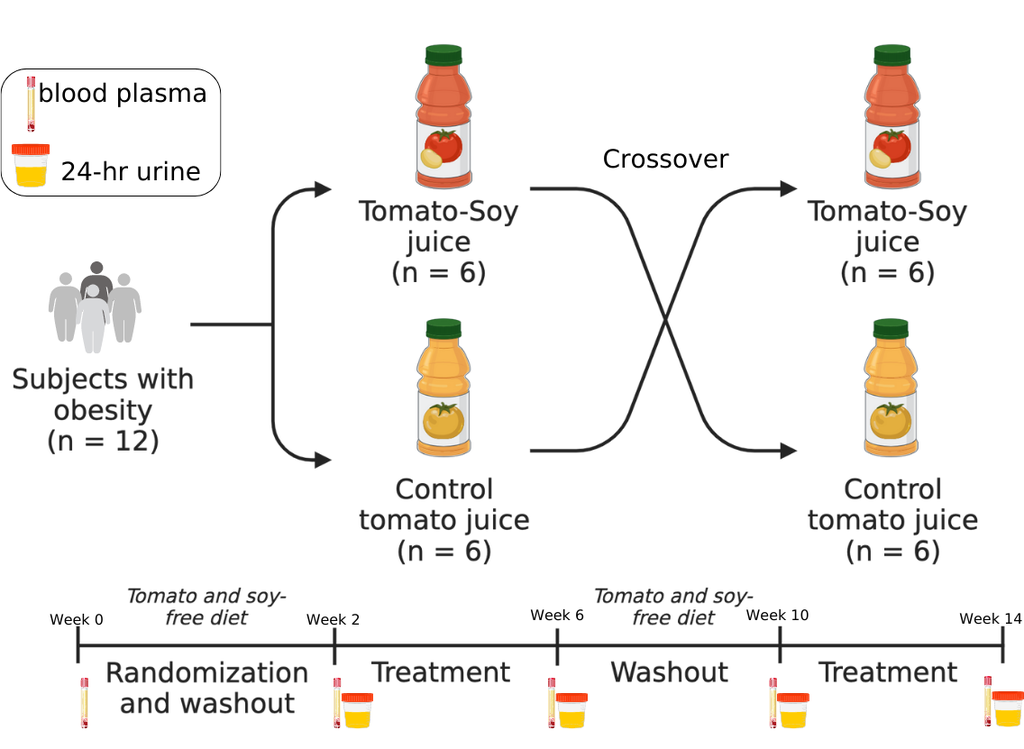

Crossover clinical trial design supplementing individuals with obesity 360 mL of a low carotenoid tomato juice or a high lycopene tomato-soy juice daily. Daily serving of low carotenoid tomato juice consisted of ~1.5mg lycopene/day while high lycopene tomato-soy juice intervention consisted of 54 mg lycopene/day in addition to 210 mg total soy isoflavones/day.

# Load libraries

```r
library(tidyverse) # data wrangling
library(readxl) # read in excel files
library(janitor) # clean up names in dataset
library(corrr) # finding correlations
library(rstatix) # stats
library(lme4) # mixed linear modeling
library(knitr) # aesthetic table viewing
library(lmerTest) # add pvalue column to lmer models
library(purrr) # create functions
library(broom.mixed) # generate tidy data frames for lmer results
library(MuMIn) # lmer model testing using AICc
library(kableExtra)
library(ggthemes)
library(ggtext)
```

# Read in data

```r
# load data
meta_table <- read_excel("CompiledData_Results_Meta.xlsx",
                         sheet = "metadata_corrected_withsequence")

# clean up variable names
meta_table <- clean_names(meta_table)
```

## Wrangle

```r
# convert variables that should be factors to factors
meta_table <- meta_table %>%
  mutate(across(.cols = c("patient_id", "period",
                          "intervention", "intervention_week",
                          "pre_post", "sex", "sequence"),
                .fns = as.factor))


# some stuff came in as characters but should be numeric
meta_table <- meta_table %>%
  mutate(across(.cols = c("il_2", "il_10", "il_13", "il_4"),
                .fns = as.numeric))



# changing factor levels for pre_post
meta_table$pre_post <- factor(meta_table$pre_post,
                              levels = c("pre", "post"))

levels(meta_table$pre_post)
```

```
## [1] "pre"  "post"
```

```r
# Calculate total_cis_lyc, total_lyc, and total_carotenoids
meta_table <- meta_table %>%
  rename(n5_cis_lyc = x5_cis_lyc) %>%
  mutate(total_cis_lyc = other_cis_lyc + n5_cis_lyc,
         total_lyc = all_trans_lyc + total_cis_lyc,
         total_carotenoids = lutein + zeaxanthin + b_cryptoxanthin +
                             a_carotene + b_carotene + total_lyc)
```

# Carotenoids

## All-trans-lyc levels

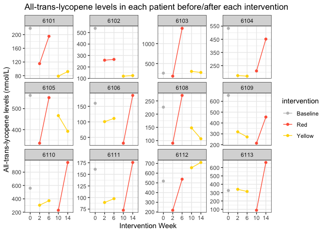

```r
# line plots for each subject at each timepoint
meta_table %>%
  ggplot(aes(x = intervention_week, y = all_trans_lyc, color = intervention)) +
  geom_point() +
  geom_line(aes(group = intervention)) +
  scale_color_manual(values = c("Baseline" = "gray",
                                           "Yellow" = "gold",
                                           "Red" = "tomato1")) +
  facet_wrap(vars(patient_id), scales = "free_y") +
  theme_bw() +
  labs(x = "Intervention Week",
       y = "All-trans-lycopene levels (nmol/L)",
       title = "All-trans-lycopene levels in each patient before/after each intervention")
```

## Total cis-lyc levels

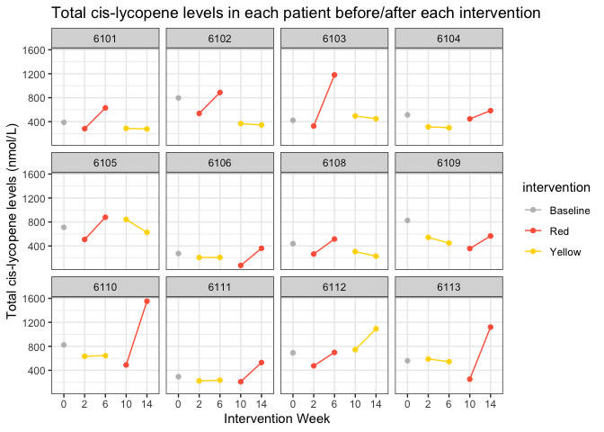

```r
# line plots for each subject at each timepoint
meta_table %>%
  ggplot(aes(x = intervention_week, y = total_cis_lyc, color = intervention)) +
  geom_point() +
  geom_line(aes(group = intervention)) +
  scale_color_manual(values = c("Baseline" = "gray",
                                           "Yellow" = "gold",
                                           "Red" = "tomato1")) +
  facet_wrap(vars(patient_id)) +
  theme_bw() +
  labs(x = "Intervention Week",
       y = "Total cis-lycopene levels (nmol/L)",
       title = "Total cis-lycopene levels in each patient before/after each intervention")
```

## Total lyc levels

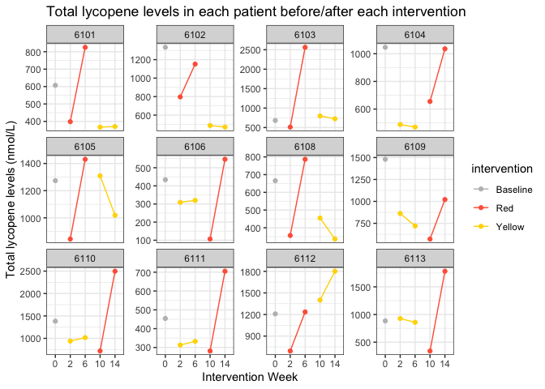

```r
# line plots for each subject at each timepoint
meta_table %>%
  ggplot(aes(x = intervention_week, y = total_lyc, color = intervention)) +
  geom_point() +
  geom_line(aes(group = intervention)) +
  scale_color_manual(values = c("Baseline" = "gray",
                                           "Yellow" = "gold",
                                           "Red" = "tomato1")) +
  facet_wrap(vars(patient_id), scales = "free_y") +
  theme_bw() +
  labs(x = "Intervention Week",
       y = "Total lycopene levels (nmol/L)",
       title = "Total lycopene levels in each patient before/after each intervention")
```

### Aggregate data

Data wrangling

```r
# create a more specific pre_post_intervention column
meta_table_edited <- meta_table %>%
  unite(col = "pre_post_intervention",
        c("pre_post","intervention"),
        sep = "_",
        remove = FALSE)

# make legend title
legendtitle_ppintervention <- "Timepoint"

# make pre_post_intervention column factors
meta_table_edited$pre_post_intervention <- as.factor(meta_table_edited$pre_post_intervention)

# relevel factor columns
meta_table_edited$pre_post_intervention <- factor(meta_table_edited$pre_post_intervention, levels = c("pre_Yellow", "post_Yellow", "pre_Red", "post_Red"))

meta_table_edited$intervention <- factor(meta_table_edited$intervention,
                                         levels = c("Yellow", "Red"))

labs_ppintervention <- c("before\ncontrol",
                         "after\ncontrol",
                         "before\nTomato-Soy",
                         "after\nTomato-Soy")
```

#### boxplots

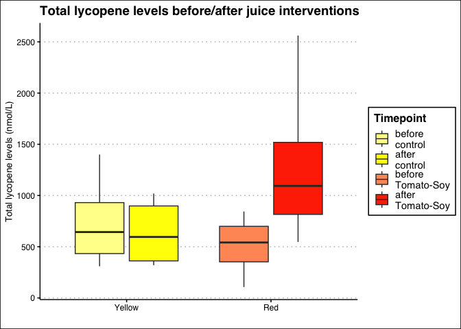

```r
meta_table_edited %>%
  filter(intervention != "Baseline") %>%
  ggplot(aes(x = intervention, y = total_lyc, fill = pre_post_intervention)) +
  geom_boxplot(outlier.shape = NA) +
  scale_fill_manual(legendtitle_ppintervention,
                    values = c("pre_Red" = "#FF9966",
                               "post_Red" = "#FF3300",
                               "pre_Yellow" = "#FFFF99",
                               "post_Yellow" = "yellow"),
                    labels = labs_ppintervention) +
  theme_clean() +
  labs(x = "",
       y = "Total lycopene levels (nmol/L)",
       title = "Total lycopene levels before/after juice interventions")
```

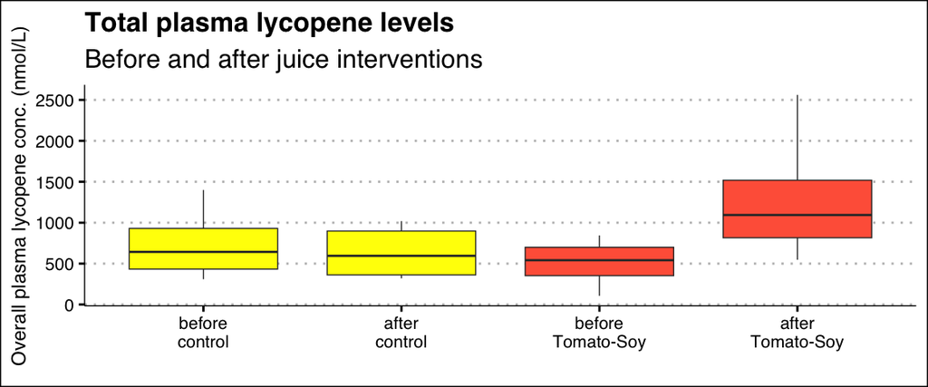

```r
meta_table_edited %>%
  filter(intervention != "Baseline") %>%
  ggplot(aes(x = pre_post_intervention, y = total_lyc, fill = intervention)) +
  geom_boxplot(outlier.shape = NA, show.legend = FALSE) +
  scale_fill_manual(values = c("Red" = "tomato1",
                               "Yellow" = "yellow1")) +
  scale_x_discrete(labels = labs_ppintervention) +
  theme_clean(base_size = 22, base_family = "sans") +
  labs(x = "",
       y = "Overall plasma lycopene conc. (nmol/L)",
       title = "Total plasma lycopene levels",
       subtitle = "Before and after juice interventions")
```

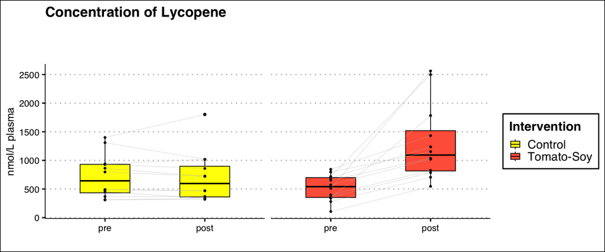

```r
library(ggpubr)

(total_lyc_levels <- meta_table_edited %>%
    filter(intervention != "Baseline") %>%
  ggpaired(x = "pre_post", y = "total_lyc", fill = "intervention", line.color = "gray", line.size = 1, facet.by = "intervention", short.panel.labs = FALSE, panel.labs = list(intervention = c("", ""))) +
  scale_fill_manual(values = c("Red" = "tomato1",
                               "Yellow" = "yellow1"),
                    labels = c("Control", "Tomato-Soy"),
                    name = "Intervention") +
  geom_line(aes(group = patient_id), colour = "gray", linewidth = 0.15) +
  theme_clean(base_size = 18, base_family = "sans") +
  labs(x = "",
       y = "nmol/L plasma",
       title = "Concentration of Lycopene",
       subtitle = ""))
```

#### export

```r
ggsave(filename = "/Users/mariasholola/Documents/GitHub/USDA-Inflammation-Metabolomics/Plots/total-lyc-red-and-yellow-boxplots.svg", plot = total_lyc_levels, width = 12)
```

### Descriptive stats

Convert df to tidy for lycopene

```r
# convert meta_table_edited to long format for lycopene
meta_table_lyc_long <- meta_table_edited %>%
  pivot_longer(cols = total_lyc,
               names_to = "total_lycopene",
               values_to = "nmol_per_L")
```

Tomato soy average and stdev

```r
meta_table_lyc_long %>%
  filter(intervention == "Red") %>%
  group_by(pre_post) %>%
  summarize(mean = mean(nmol_per_L),
            stdev = sd(nmol_per_L))
```

```
## # A tibble: 2 × 3
##   pre_post  mean stdev
##   <fct>    <dbl> <dbl>
## 1 pre       523.  228.
## 2 post     1298.  665.
```

Low carotenoid average and stdev

```r
meta_table_lyc_long %>%
  filter(intervention == "Yellow") %>%
  group_by(pre_post) %>%
  summarize(mean = mean(nmol_per_L),
            stdev = sd(nmol_per_L))
```

```
## # A tibble: 2 × 3
##   pre_post  mean stdev
##   <fct>    <dbl> <dbl>
## 1 pre       721.  377.
## 2 post      703.  434.
```

Fold increase subject-wise on each intervention

```r
lyc_long_subset <- meta_table_lyc_long %>%
  select(patient_id, intervention, pre_post, nmol_per_L) %>%
  unite("intervention_pre_post", intervention:pre_post) %>%
  pivot_wider(names_from = intervention_pre_post,
              values_from = nmol_per_L) %>%
  mutate(red_FC = Red_post/Red_pre,
         yellow_FC = Yellow_post/Yellow_pre)

lyc_long_subset %>%
  summarize(mean_red_FC = mean(red_FC),
            mean_yellow_FC = mean(yellow_FC))
```

```
## # A tibble: 1 × 2
##   mean_red_FC mean_yellow_FC
##         <dbl>          <dbl>
## 1        2.83          0.966
```

#### Normality checks

Plot histogram

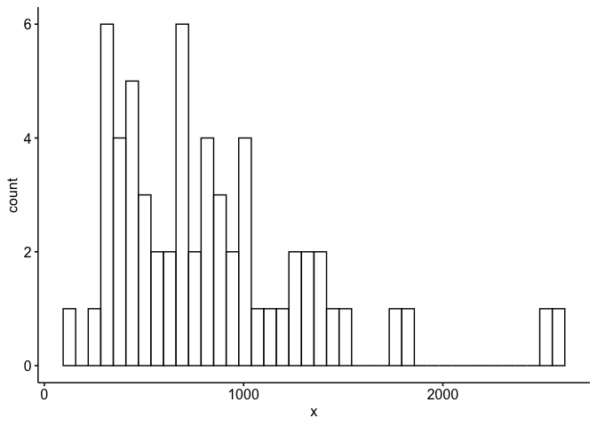

```r
gghistogram(meta_table_lyc_long$nmol_per_L, bins = 40)
```

Shapiro’s normality test

```r
# shapiro normality test for total lycopene
meta_table_lyc_long %>%
  group_by(total_lycopene) %>%
  shapiro_test(vars = "nmol_per_L")
```

```
## # A tibble: 1 × 4
##   total_lycopene variable   statistic         p
##   <chr>          <chr>          <dbl>     <dbl>
## 1 total_lyc      nmol_per_L     0.886 0.0000410
```

P val for shapiro test turned out to < 0.05, meaning data here is not normal. I will run the non-parametric alternative to paired t-tests, Wilcoxon’s test.

#### Compare means

```r
# wilcoxon's rank-sum test
compare_means(nmol_per_L ~ pre_post, meta_table_lyc_long, method = "wilcox.test", paired = TRUE, group.by = "intervention")
```

```
## # A tibble: 2 × 9
##   intervention .y.        group1 group2        p  p.adj p.format p.signif method
##   <fct>        <chr>      <chr>  <chr>     <dbl>  <dbl> <chr>    <chr>    <chr>
## 1 Red          nmol_per_L pre    post   0.000488 9.8e-4 0.00049  ***      Wilco…
## 2 Yellow       nmol_per_L pre    post   0.424    4.2e-1 0.42383  ns       Wilco…
```

## Total carotenoid levels

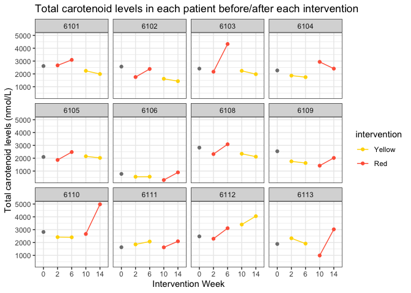

```r
meta_table_edited %>%
  ggplot(aes(x = intervention_week, y = total_carotenoids, color = intervention)) +
  geom_point() +
  geom_line(aes(group = intervention)) +
  scale_color_manual(values = c("Baseline" = "gray",
                                           "Yellow" = "gold",
                                           "Red" = "tomato1")) +
  facet_wrap(vars(patient_id)) +
  theme_bw() +
  labs(x = "Intervention Week",
       y = "Total carotenoid levels (nmol/L)",
       title = "Total carotenoid levels in each patient before/after each intervention")
```

**Patient 6112 carotenoid levels go up after control intervention.**

# Cytokines

Wrangle

```r
# convert cytokines from wide to long
meta_cytokines_long <- meta_table_edited %>%
  pivot_longer(cols = if_ng:il_4,
               names_to = "cytokines",
               values_to = "cyto_conc_pg_ml")
```

## Carryover effects?

First, let’s test for sequence effects. We hope to not have this problem since we feel that the washout period of 4 weeks was sufficient enough for the intervention to not have lingering effects on cytokine levels.

### Normality check

```r
meta_cytokines_long %>%
  group_by(sequence) %>%
  shapiro_test(cyto_conc_pg_ml)
```

```
## # A tibble: 2 × 4
##   sequence variable        statistic        p
##   <fct>    <chr>               <dbl>    <dbl>
## 1 R_Y      cyto_conc_pg_ml     0.584 9.00e-28
## 2 Y_R      cyto_conc_pg_ml     0.502 1.30e-29
```

Data is not normally distributed, so will use nonparametric paired tests for this test.

### Wilcoxon rank-sum

```r
(wilcox_cyto_seqeffects <- meta_cytokines_long %>%
   filter(intervention != "Baseline") %>%
   group_by(period) %>%
   wilcox_test(cyto_conc_pg_ml ~ sequence, paired = TRUE, p.adjust.method = "BH"))
```

```
## # A tibble: 4 × 8
##   period .y.             group1 group2    n1    n2 statistic     p
## * <fct>  <chr>           <chr>  <chr>  <int> <int>     <dbl> <dbl>
## 1 B1     cyto_conc_pg_ml R_Y    Y_R       87    84     1883  0.403
## 2 B2     cyto_conc_pg_ml R_Y    Y_R       85    84     1495  0.55
## 3 B3     cyto_conc_pg_ml R_Y    Y_R       84    83     1888. 0.199
## 4 B4     cyto_conc_pg_ml R_Y    Y_R       85    84     1824  0.443
```

Within each period, sequence does not significantly effect the outcome. Therefore we can continue to assume there are no sequence effects.

## Intervention effects

Here, we look at significant differences between post-tomatosoy and post-yellow.

### Normality check

```r
meta_cytokines_long %>%
  filter(pre_post == "post") %>%
  group_by(cytokines) %>%
  shapiro_test(cyto_conc_pg_ml)
```

```
## # A tibble: 15 × 4
##    cytokines variable        statistic            p
##    <chr>     <chr>               <dbl>        <dbl>
##  1 gm_csf    cyto_conc_pg_ml     0.725 0.0000221
##  2 if_ng     cyto_conc_pg_ml     0.721 0.0000191
##  3 il_10     cyto_conc_pg_ml     0.703 0.0000153
##  4 il_12p40  cyto_conc_pg_ml     0.862 0.00363
##  5 il_12p70  cyto_conc_pg_ml     0.492 0.0000000473
##  6 il_13     cyto_conc_pg_ml     0.743 0.000189
##  7 il_1b     cyto_conc_pg_ml     0.752 0.0000529
##  8 il_1ra    cyto_conc_pg_ml     0.931 0.102
##  9 il_2      cyto_conc_pg_ml     0.793 0.00219
## 10 il_4      cyto_conc_pg_ml     0.740 0.000480
## 11 il_5      cyto_conc_pg_ml     0.777 0.000129
## 12 il_6      cyto_conc_pg_ml     0.666 0.00000372
## 13 il_8      cyto_conc_pg_ml     0.967 0.597
## 14 mcp_1     cyto_conc_pg_ml     0.935 0.123
## 15 tn_fa     cyto_conc_pg_ml     0.843 0.00164
```

In this case, many cytokines are not normally distributed. So I’ll go forward with non-parametric paired tests.

### Wilxocon rank-sum

```r
(wilcox_cyto_intervention <- meta_cytokines_long %>%
  filter(pre_post == "post") %>%
  group_by(cytokines) %>%
  wilcox_test(cyto_conc_pg_ml ~ intervention, paired = TRUE, p.adjust.method = "BH"))
```

```
## # A tibble: 15 × 8
##    cytokines .y.             group1 group2    n1    n2 statistic     p
##  * <chr>     <chr>           <chr>  <chr>  <int> <int>     <dbl> <dbl>
##  1 gm_csf    cyto_conc_pg_ml Yellow Red       12    12      39   1
##  2 if_ng     cyto_conc_pg_ml Yellow Red       12    12      39   1
##  3 il_10     cyto_conc_pg_ml Yellow Red       11    12      32   0.683
##  4 il_12p40  cyto_conc_pg_ml Yellow Red       12    12      48   0.519
##  5 il_12p70  cyto_conc_pg_ml Yellow Red       12    12      46   0.622
##  6 il_13     cyto_conc_pg_ml Yellow Red       10     9      18   1
##  7 il_1b     cyto_conc_pg_ml Yellow Red       12    12      45   0.677
##  8 il_1ra    cyto_conc_pg_ml Yellow Red       12    12      47   0.569
##  9 il_2      cyto_conc_pg_ml Yellow Red        8     8       7   1
## 10 il_4      cyto_conc_pg_ml Yellow Red        8     8       8   0.688
## 11 il_5      cyto_conc_pg_ml Yellow Red       12    12      49   0.47
## 12 il_6      cyto_conc_pg_ml Yellow Red       12    12      47.5 0.53
## 13 il_8      cyto_conc_pg_ml Yellow Red       12    12      40   0.97
## 14 mcp_1     cyto_conc_pg_ml Yellow Red       12    12      44   0.733
## 15 tn_fa     cyto_conc_pg_ml Yellow Red       12    12      40   0.97
```

```r
# extract statistically significant cytokines
wilcox_cyto_intervention %>%
  filter(wilcox_cyto_intervention$p < 0.05)
```

```
## # A tibble: 0 × 8
## # ℹ 8 variables: cytokines <chr>, .y. <chr>, group1 <chr>, group2 <chr>,
## #   n1 <int>, n2 <int>, statistic <dbl>, p <dbl>
```

- There are no cytokines with significantly different levels when comparing post-red vs. post-yellow treatment
- Moving forward, I will use wilcoxon rank sum tests for the rest of the tests under the assumption that all of the variables are not normally distributed.

## Yellow treatment effects

### Normality check

```r
meta_cytokines_long %>%
  filter(intervention == "Yellow") %>%
  group_by(cytokines) %>%
  shapiro_test(cyto_conc_pg_ml)
```

```
## # A tibble: 15 × 4
##    cytokines variable        statistic             p
##    <chr>     <chr>               <dbl>         <dbl>
##  1 gm_csf    cyto_conc_pg_ml     0.581 0.000000379
##  2 if_ng     cyto_conc_pg_ml     0.601 0.000000640
##  3 il_10     cyto_conc_pg_ml     0.752 0.0000967
##  4 il_12p40  cyto_conc_pg_ml     0.832 0.00101
##  5 il_12p70  cyto_conc_pg_ml     0.390 0.00000000565
##  6 il_13     cyto_conc_pg_ml     0.710 0.000103
##  7 il_1b     cyto_conc_pg_ml     0.755 0.0000593
##  8 il_1ra    cyto_conc_pg_ml     0.669 0.00000400
##  9 il_2      cyto_conc_pg_ml     0.584 0.00000729
## 10 il_4      cyto_conc_pg_ml     0.685 0.000116
## 11 il_5      cyto_conc_pg_ml     0.685 0.00000633
## 12 il_6      cyto_conc_pg_ml     0.669 0.00000401
## 13 il_8      cyto_conc_pg_ml     0.969 0.653
## 14 mcp_1     cyto_conc_pg_ml     0.931 0.104
## 15 tn_fa     cyto_conc_pg_ml     0.654 0.00000263
```

### Wilcoxon rank-sum

```r
(wilcox_cyto_yellow <- meta_cytokines_long %>%
  filter(intervention == "Yellow") %>%
  group_by(cytokines) %>%
  wilcox_test(cyto_conc_pg_ml ~ pre_post, paired = TRUE, p.adjust.method = "BH"))
```

```
## # A tibble: 15 × 8
##    cytokines .y.             group1 group2    n1    n2 statistic     p
##  * <chr>     <chr>           <chr>  <chr>  <int> <int>     <dbl> <dbl>
##  1 gm_csf    cyto_conc_pg_ml pre    post      12    12      54   0.266
##  2 if_ng     cyto_conc_pg_ml pre    post      12    12      52   0.339
##  3 il_10     cyto_conc_pg_ml pre    post      11    11      29   0.922
##  4 il_12p40  cyto_conc_pg_ml pre    post      12    12      34.5 0.929
##  5 il_12p70  cyto_conc_pg_ml pre    post      12    12      33   1
##  6 il_13     cyto_conc_pg_ml pre    post       8    10      19.5 0.889
##  7 il_1b     cyto_conc_pg_ml pre    post      12    12      41   0.185
##  8 il_1ra    cyto_conc_pg_ml pre    post      12    12      59   0.129
##  9 il_2      cyto_conc_pg_ml pre    post       9     8      26   0.313
## 10 il_4      cyto_conc_pg_ml pre    post       8     8      28   0.195
## 11 il_5      cyto_conc_pg_ml pre    post      12    12      31   0.569
## 12 il_6      cyto_conc_pg_ml pre    post      12    12      54   0.266
## 13 il_8      cyto_conc_pg_ml pre    post      12    12      34   0.733
## 14 mcp_1     cyto_conc_pg_ml pre    post      12    12      34   0.733
## 15 tn_fa     cyto_conc_pg_ml pre    post      12    12      40   0.97
```

```r
# extract statistically significant cytokines
wilcox_cyto_yellow %>%
  filter(wilcox_cyto_yellow$p < 0.05)
```

```
## # A tibble: 0 × 8
## # ℹ 8 variables: cytokines <chr>, .y. <chr>, group1 <chr>, group2 <chr>,
## #   n1 <int>, n2 <int>, statistic <dbl>, p <dbl>
```

- No significant cytokines within yellow treatment

## Red treatment effects

### Normality check

```r
meta_cytokines_long %>%
  filter(intervention == "Red") %>%
  group_by(cytokines) %>%
  shapiro_test(cyto_conc_pg_ml)
```

```
## # A tibble: 15 × 4
##    cytokines variable        statistic            p
##    <chr>     <chr>               <dbl>        <dbl>
##  1 gm_csf    cyto_conc_pg_ml     0.628 0.00000128
##  2 if_ng     cyto_conc_pg_ml     0.573 0.000000317
##  3 il_10     cyto_conc_pg_ml     0.717 0.0000237
##  4 il_12p40  cyto_conc_pg_ml     0.891 0.0139
##  5 il_12p70  cyto_conc_pg_ml     0.429 0.0000000124
##  6 il_13     cyto_conc_pg_ml     0.732 0.000136
##  7 il_1b     cyto_conc_pg_ml     0.746 0.0000440
##  8 il_1ra    cyto_conc_pg_ml     0.871 0.00551
##  9 il_2      cyto_conc_pg_ml     0.644 0.0000284
## 10 il_4      cyto_conc_pg_ml     0.736 0.000435
## 11 il_5      cyto_conc_pg_ml     0.736 0.0000312
## 12 il_6      cyto_conc_pg_ml     0.625 0.00000120
## 13 il_8      cyto_conc_pg_ml     0.949 0.252
## 14 mcp_1     cyto_conc_pg_ml     0.927 0.0832
## 15 tn_fa     cyto_conc_pg_ml     0.696 0.00000893
```

```r
(wilcox_cyto_red <-  meta_cytokines_long %>%
  filter(intervention == "Red") %>%
  group_by(cytokines) %>%
  wilcox_test(cyto_conc_pg_ml ~ pre_post, paired = TRUE, p.adjust.method = "BH"))
```

```
## # A tibble: 15 × 8
##    cytokines .y.             group1 group2    n1    n2 statistic      p
##  * <chr>     <chr>           <chr>  <chr>  <int> <int>     <dbl>  <dbl>
##  1 gm_csf    cyto_conc_pg_ml pre    post      12    12      65   0.0425
##  2 if_ng     cyto_conc_pg_ml pre    post      12    12      49   0.168
##  3 il_10     cyto_conc_pg_ml pre    post      11    12      45   0.32
##  4 il_12p40  cyto_conc_pg_ml pre    post      12    12      61   0.0923
##  5 il_12p70  cyto_conc_pg_ml pre    post      12    12      66   0.0376
##  6 il_13     cyto_conc_pg_ml pre    post      10     9      26   0.313
##  7 il_1b     cyto_conc_pg_ml pre    post      12    12      48   0.197
##  8 il_1ra    cyto_conc_pg_ml pre    post      12    12      44   0.733
##  9 il_2      cyto_conc_pg_ml pre    post       9     8      22   0.641
## 10 il_4      cyto_conc_pg_ml pre    post       8     8      26   0.313
## 11 il_5      cyto_conc_pg_ml pre    post      12    12      65   0.0425
## 12 il_6      cyto_conc_pg_ml pre    post      12    12      57   0.176
## 13 il_8      cyto_conc_pg_ml pre    post      12    12      31.5 0.583
## 14 mcp_1     cyto_conc_pg_ml pre    post      12    12      38   0.97
## 15 tn_fa     cyto_conc_pg_ml pre    post      12    12      64   0.0522
```

```r
# extract statistically significant cytokines
wilcox_cyto_red %>%
  filter(wilcox_cyto_red$p < 0.05)
```

```
## # A tibble: 3 × 8
##   cytokines .y.             group1 group2    n1    n2 statistic      p
##   <chr>     <chr>           <chr>  <chr>  <int> <int>     <dbl>  <dbl>
## 1 gm_csf    cyto_conc_pg_ml pre    post      12    12        65 0.0425
## 2 il_12p70  cyto_conc_pg_ml pre    post      12    12        66 0.0376
## 3 il_5      cyto_conc_pg_ml pre    post      12    12        65 0.0425
```

- There are 3 cytokines (GM-CSF, IL-12p70, and IL-5) significantly different between pre and post-Red interventions only. Lets investigate.

#### GM-CSF

##### boxplots

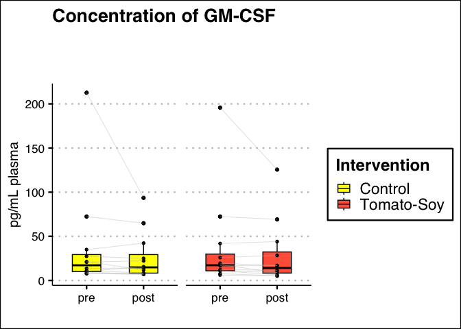

```r
meta_cytokines_long %>%
   filter(cytokines == "gm_csf") %>%
  filter(intervention != "Baseline") %>%
  ggpaired(x = "pre_post", y = "cyto_conc_pg_ml", fill = "intervention", facet.by = "intervention", short.panel.labs = FALSE, panel.labs = list(intervention = c("", ""))) +
  scale_fill_manual(values = c("Red" = "tomato1",
                               "Yellow" = "yellow1"),
                    labels = c("Control", "Tomato-Soy"),
                    name = "Intervention") +
  geom_line(aes(group = patient_id), colour = "gray", size = 0.15) +
  theme_clean(base_size = 18, base_family = "sans") +
  labs(x = "",
       y = "pg/mL plasma",
       title = "Concentration of GM-CSF",
       subtitle = "")
```

One subject has much higher levels than others. Let’s run a log2 transformation to get a better visual idea of what is happening with the rest.

```r
meta_logcytokines_long <- meta_cytokines_long %>%
  mutate(log2_cyto_conc_pg_ml = log2(cyto_conc_pg_ml))
```

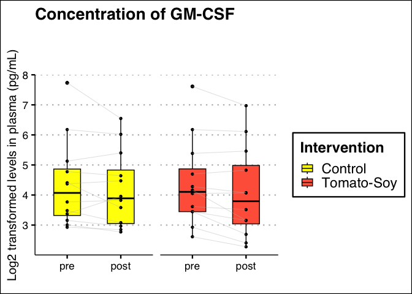

```r
meta_logcytokines_long %>%
   filter(cytokines == "gm_csf") %>%
  filter(intervention != "Baseline") %>%
  ggpaired(x = "pre_post", y = "log2_cyto_conc_pg_ml", fill = "intervention", facet.by = "intervention", short.panel.labs = FALSE, panel.labs = list(intervention = c("", ""))) +
  scale_fill_manual(values = c("Red" = "tomato1",
                               "Yellow" = "yellow1"),
                    labels = c("Control", "Tomato-Soy"),
                    name = "Intervention") +
  geom_line(aes(group = patient_id), colour = "gray", size = 0.15) +
  theme_clean(base_size = 18, base_family = "sans") +
  labs(x = "",
       y = "Log2 transformed levels in plasma (pg/mL)",
       title = "Concentration of GM-CSF",
       subtitle = "")
```

What do GM-CSF levels look like between interventions?

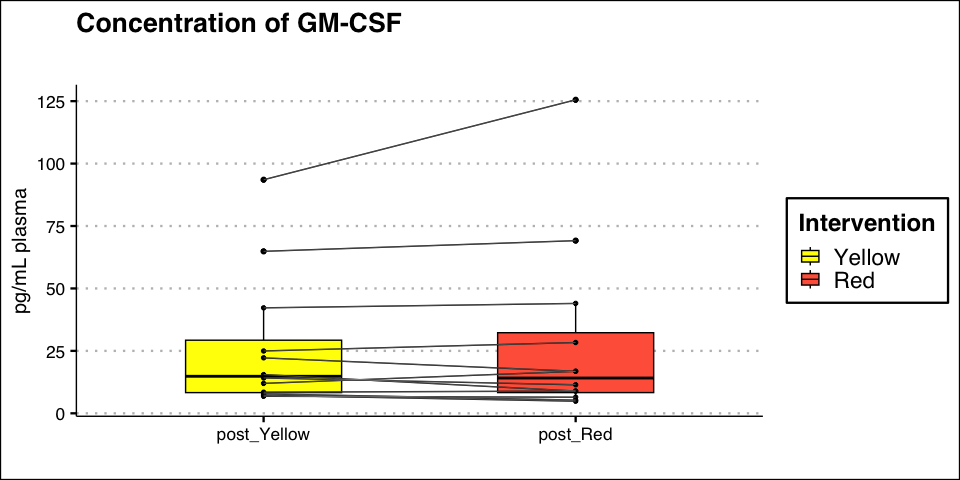

```r
(total_GM_CSF_levels_postred_v_postyellow <- meta_cytokines_long %>%
   filter(cytokines == "gm_csf") %>%
   filter(pre_post == "post") %>%
  ggpaired(x = "pre_post_intervention", y = "cyto_conc_pg_ml", fill = "intervention", short.panel.labs = FALSE, panel.labs = list(intervention = c("", ""))) +
  scale_fill_manual(values = c("Red" = "tomato1",
                               "Yellow" = "yellow1"),
                    name = "Intervention") +
  geom_line(aes(group = patient_id), colour = "gray", size = 0.15) +
  theme_clean(base_size = 18, base_family = "sans") +
  labs(x = "",
       y = "pg/mL plasma",
       title = "Concentration of GM-CSF",
       subtitle = ""))
```

##### fold change

What is the avg fold change in the red intervention?

```r
red_gmcsf_cyto_subset <- meta_cytokines_long %>%
  filter(intervention == "Red") %>%
  filter(cytokines == "gm_csf") %>%
  drop_na() %>%
  select(patient_id, intervention, pre_post_intervention, cyto_conc_pg_ml) %>%
  pivot_wider(names_from = pre_post_intervention,
              values_from = cyto_conc_pg_ml) %>%
  mutate(red_FC = post_Red/pre_Red)

red_gmcsf_cyto_subset %>%
  summarize(mean_red_FC = mean(red_FC))
```

```
## # A tibble: 1 × 1
##   mean_red_FC
##         <dbl>
## 1       0.830
```

What about within the yellow?

```r
yellow_gmcsf_cyto_subset <- meta_cytokines_long %>%
  filter(intervention == "Yellow") %>%
  filter(cytokines == "gm_csf") %>%
  select(patient_id, intervention, pre_post_intervention, cyto_conc_pg_ml) %>%
  pivot_wider(names_from = pre_post_intervention,
              values_from = cyto_conc_pg_ml) %>%
  mutate(yellow_FC = post_Yellow/pre_Yellow)

yellow_gmcsf_cyto_subset %>%
  summarize(mean_yellow_FC = mean(yellow_FC))
```

```
## # A tibble: 1 × 1
##   mean_yellow_FC
##            <dbl>
## 1          0.922
```

#### IL-12p70

##### boxplots

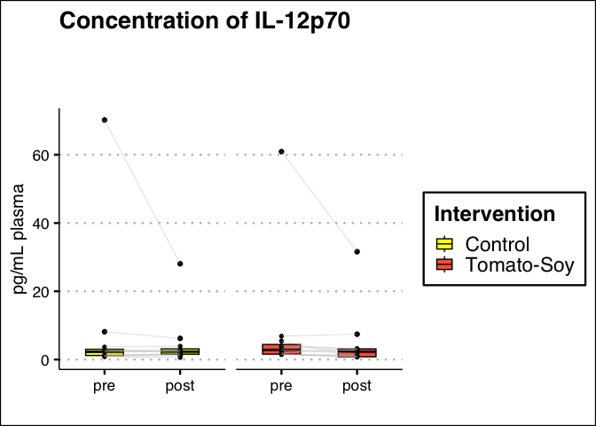

```r
meta_cytokines_long %>%
   filter(cytokines == "il_12p70") %>%
  filter(intervention != "Baseline") %>%
  ggpaired(x = "pre_post", y = "cyto_conc_pg_ml", fill = "intervention", facet.by = "intervention", short.panel.labs = FALSE, panel.labs = list(intervention = c("", ""))) +
  scale_fill_manual(values = c("Red" = "tomato1",
                               "Yellow" = "yellow1"),
                    labels = c("Control", "Tomato-Soy"),
                    name = "Intervention") +
  geom_line(aes(group = patient_id), colour = "gray", size = 0.15) +
  theme_clean(base_size = 18, base_family = "sans") +
  labs(x = "",
       y = "pg/mL plasma",
       title = "Concentration of IL-12p70",
       subtitle = "")
```

Again, one subj is extremely high. So we will log2 transform for visualization purposes.

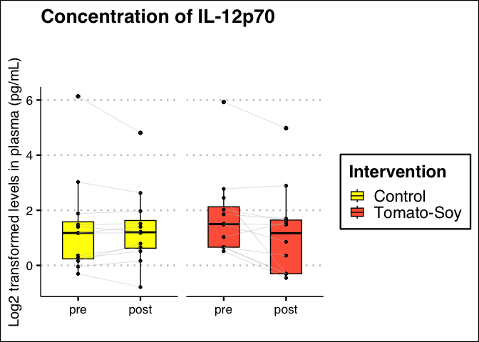

```r
meta_logcytokines_long %>%
   filter(cytokines == "il_12p70") %>%
  filter(intervention != "Baseline") %>%
  ggpaired(x = "pre_post", y = "log2_cyto_conc_pg_ml", fill = "intervention", facet.by = "intervention", short.panel.labs = FALSE, panel.labs = list(intervention = c("", ""))) +
  scale_fill_manual(values = c("Red" = "tomato1",
                               "Yellow" = "yellow1"),
                    labels = c("Control", "Tomato-Soy"),
                    name = "Intervention") +
  geom_line(aes(group = patient_id), colour = "gray", size = 0.15) +
  theme_clean(base_size = 18, base_family = "sans") +
  labs(x = "",
       y = "Log2 transformed levels in plasma (pg/mL)",
       title = "Concentration of IL-12p70",
       subtitle = "")
```

What do IL-12p70 levels look like between interventions?

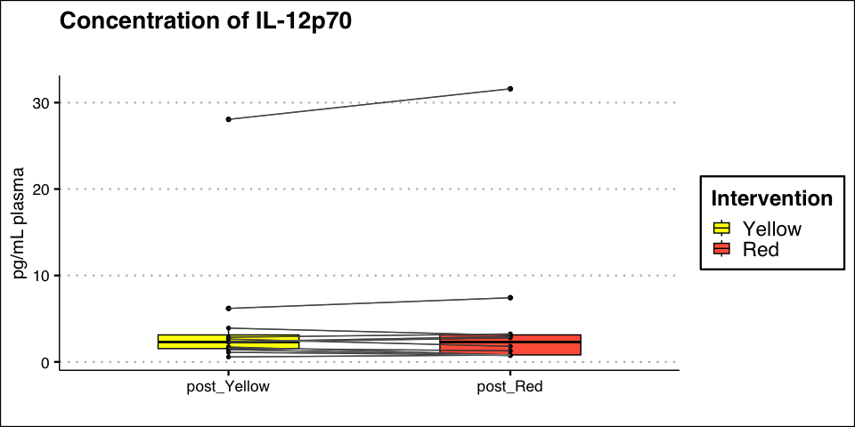

```r
(total_IL12p70_levels_postred_v_postyellow <- meta_cytokines_long %>%
   filter(cytokines == "il_12p70") %>%
   filter(pre_post == "post") %>%
  ggpaired(x = "pre_post_intervention", y = "cyto_conc_pg_ml", fill = "intervention", short.panel.labs = FALSE, panel.labs = list(intervention = c("", ""))) +
  scale_fill_manual(values = c("Red" = "tomato1",
                               "Yellow" = "yellow1"),
                    name = "Intervention") +
  geom_line(aes(group = patient_id), colour = "gray", size = 0.15) +
  theme_clean(base_size = 18, base_family = "sans") +
  labs(x = "",
       y = "pg/mL plasma",
       title = "Concentration of IL-12p70",
       subtitle = ""))
```

##### fold change

What is the avg fold change in the red intervention?

```r
red_il_12p70_cyto_subset <- meta_cytokines_long %>%
  filter(intervention == "Red") %>%
  filter(cytokines == "il_12p70") %>%
  drop_na() %>%
  select(patient_id, intervention, pre_post_intervention, cyto_conc_pg_ml) %>%
  pivot_wider(names_from = pre_post_intervention,
              values_from = cyto_conc_pg_ml) %>%
  mutate(red_FC = post_Red/pre_Red)

red_il_12p70_cyto_subset %>%
  summarize(mean_red_FC = mean(red_FC))
```

```
## # A tibble: 1 × 1
##   mean_red_FC
##         <dbl>
## 1       0.735
```

What about within the yellow?

```r
yellow_il_12p70_cyto_subset <- meta_cytokines_long %>%
  filter(intervention == "Yellow") %>%
  filter(cytokines == "il_12p70") %>%
  select(patient_id, intervention, pre_post_intervention, cyto_conc_pg_ml) %>%
  pivot_wider(names_from = pre_post_intervention,
              values_from = cyto_conc_pg_ml) %>%
  mutate(yellow_FC = post_Yellow/pre_Yellow)

yellow_il_12p70_cyto_subset %>%
  summarize(mean_yellow_FC = mean(yellow_FC))
```

```
## # A tibble: 1 × 1
##   mean_yellow_FC
##            <dbl>
## 1           1.01
```

#### IL-5

##### boxplots

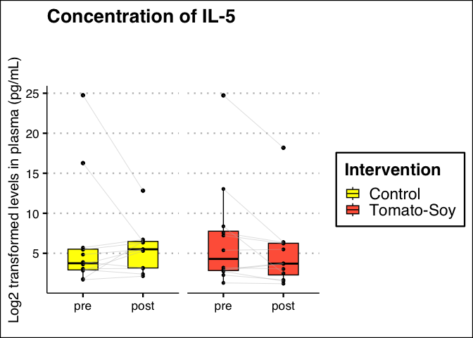

```r
(total_IL5_levels <- meta_cytokines_long %>%
   filter(cytokines == "il_5") %>%
  filter(intervention != "Baseline") %>%
  ggpaired(x = "pre_post", y = "cyto_conc_pg_ml", fill = "intervention", facet.by = "intervention", short.panel.labs = FALSE, panel.labs = list(intervention = c("", ""))) +
  scale_fill_manual(values = c("Red" = "tomato1",
                               "Yellow" = "yellow1"),
                    labels = c("Control", "Tomato-Soy"),
                    name = "Intervention") +
  geom_line(aes(group = patient_id), colour = "gray", size = 0.15) +
  theme_clean(base_size = 18, base_family = "sans") +
  labs(x = "",
       y = "Log2 transformed levels in plasma (pg/mL)",
       title = "Concentration of IL-5",
       subtitle = ""))
```

```r
ggsave(filename = "/Users/mariasholola/Documents/GitHub/USDA-Inflammation-Metabolomics/Plots/total-IL5-levels-red-yellow.svg", plot = total_IL5_levels, width = 10)
```

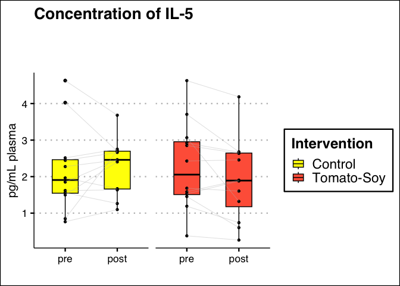

```r
meta_logcytokines_long %>%
   filter(cytokines == "il_5") %>%
  filter(intervention != "Baseline") %>%
  ggpaired(x = "pre_post", y = "log2_cyto_conc_pg_ml", fill = "intervention", facet.by = "intervention", short.panel.labs = FALSE, panel.labs = list(intervention = c("", ""))) +
  scale_fill_manual(values = c("Red" = "tomato1",
                               "Yellow" = "yellow1"),
                    labels = c("Control", "Tomato-Soy"),
                    name = "Intervention") +
  geom_line(aes(group = patient_id), colour = "gray", size = 0.15) +
  theme_clean(base_size = 18, base_family = "sans") +
  labs(x = "",
       y = "pg/mL plasma",
       title = "Concentration of IL-5",
       subtitle = "")
```

What do IL-5 levels look like between interventions?

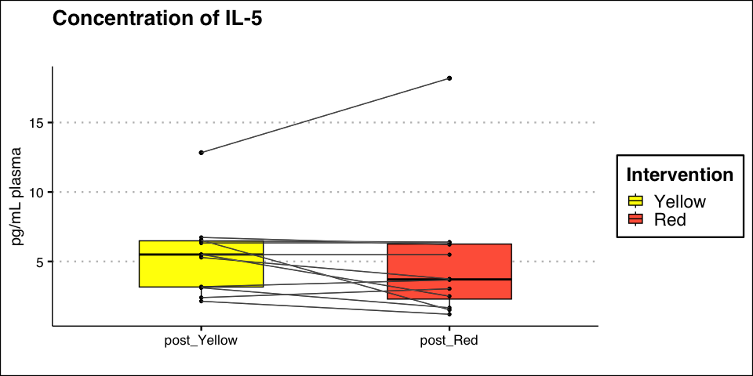

```r
(total_IL5_levels_postred_v_postyellow <- meta_cytokines_long %>%
   filter(cytokines == "il_5") %>%
   filter(pre_post == "post") %>%
  ggpaired(x = "pre_post_intervention", y = "cyto_conc_pg_ml", fill = "intervention", short.panel.labs = FALSE, panel.labs = list(intervention = c("", ""))) +
  scale_fill_manual(values = c("Red" = "tomato1",
                               "Yellow" = "yellow1"),
                    name = "Intervention") +
  geom_line(aes(group = patient_id), colour = "gray", size = 0.15) +
  theme_clean(base_size = 18, base_family = "sans") +
  labs(x = "",
       y = "pg/mL plasma",
       title = "Concentration of IL-5",
       subtitle = ""))
```

##### fold change

What is the avg fold change in the red intervention?

```r
red_il_5_cyto_subset <- meta_cytokines_long %>%
  filter(intervention == "Red") %>%
  filter(cytokines == "il_5") %>%
  drop_na() %>%
  select(patient_id, intervention, pre_post_intervention, cyto_conc_pg_ml) %>%
  pivot_wider(names_from = pre_post_intervention,
              values_from = cyto_conc_pg_ml) %>%
  mutate(red_FC = post_Red/pre_Red)

red_il_5_cyto_subset %>%
  summarize(mean_red_FC = mean(red_FC))
```

```
## # A tibble: 1 × 1
##   mean_red_FC
##         <dbl>
## 1       0.828
```

What about within the yellow?

```r
yellow_il_5_cyto_subset <- meta_cytokines_long %>%
  filter(intervention == "Yellow") %>%
  filter(cytokines == "il_5") %>%
  select(patient_id, intervention, pre_post_intervention, cyto_conc_pg_ml) %>%
  pivot_wider(names_from = pre_post_intervention,
              values_from = cyto_conc_pg_ml) %>%
  mutate(yellow_FC = post_Yellow/pre_Yellow)

yellow_il_5_cyto_subset %>%
  summarize(mean_yellow_FC = mean(yellow_FC))
```

```
## # A tibble: 1 × 1
##   mean_yellow_FC
##            <dbl>
## 1           1.28
```

### Correlation w/ carotenoids

```r
correlation_cyto_red <- meta_table %>%
  filter(intervention == "Red") %>%
  select(total_lyc, total_carotenoids, b_carotene, total_cis_lyc, a_carotene, lutein, zeaxanthin, b_cryptoxanthin, il_5, il_12p70, gm_csf) %>%
  correlate()

kable(correlation_cyto_red, format = "markdown", digits = 3)
```

| term | total_lyc | total_carotenoids | b_carotene | total_cis_lyc | a_carotene | lutein | zeaxanthin | b_cryptoxanthin | il_5 | il_12p70 | gm_csf |
| --- | --- | --- | --- | --- | --- | --- | --- | --- | --- | --- | --- |
| total_lyc | NA | 0.801 | 0.200 | 0.968 | 0.033 | 0.370 | -0.094 | 0.257 | 0.218 | 0.002 | 0.077 |
| total_carotenoids | 0.801 | NA | 0.679 | 0.805 | 0.455 | 0.784 | 0.202 | 0.420 | 0.305 | -0.123 | -0.118 |
| b_carotene | 0.200 | 0.679 | NA | 0.280 | 0.531 | 0.740 | 0.312 | 0.068 | 0.206 | -0.184 | -0.274 |
| total_cis_lyc | 0.968 | 0.805 | 0.280 | NA | 0.071 | 0.395 | -0.097 | 0.190 | 0.299 | 0.075 | 0.156 |
| a_carotene | 0.033 | 0.455 | 0.531 | 0.071 | NA | 0.655 | 0.486 | 0.122 | 0.489 | -0.118 | -0.231 |
| lutein | 0.370 | 0.784 | 0.740 | 0.395 | 0.655 | NA | 0.309 | 0.231 | 0.329 | -0.232 | -0.264 |
| zeaxanthin | -0.094 | 0.202 | 0.312 | -0.097 | 0.486 | 0.309 | NA | 0.089 | 0.209 | 0.384 | 0.287 |
| b_cryptoxanthin | 0.257 | 0.420 | 0.068 | 0.190 | 0.122 | 0.231 | 0.089 | NA | -0.077 | -0.108 | -0.059 |
| il_5 | 0.218 | 0.305 | 0.206 | 0.299 | 0.489 | 0.329 | 0.209 | -0.077 | NA | 0.273 | 0.281 |
| il_12p70 | 0.002 | -0.123 | -0.184 | 0.075 | -0.118 | -0.232 | 0.384 | -0.108 | 0.273 | NA | 0.933 |
| gm_csf | 0.077 | -0.118 | -0.274 | 0.156 | -0.231 | -0.264 | 0.287 | -0.059 | 0.281 | 0.933 | NA |

No strong correlation between the significant cytokines and carotenoids. Let’s still visualize what the trends look like in both interventions.

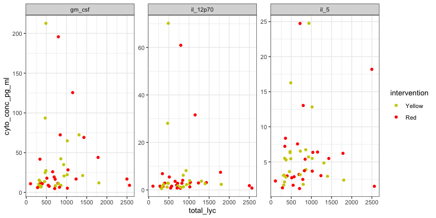

```r
sig_cytokines_red <- meta_cytokines_long %>%
  filter(cytokines %in% c("il_5", "gm_csf", "il_12p70"))

sig_cytokines_red %>%
  ggplot(aes(x = total_lyc, y = cyto_conc_pg_ml, color = intervention)) +
  geom_point() +
  scale_color_manual(values = c("Yellow" = "yellow3",
                                "Red" = "red")) +
  theme_bw() +
  facet_wrap(vars(cytokines), scales = "free")
```

No differences between the trends.

# Immune Cells

```r
# convert immune cell data from wide to long
meta_cells_long <- meta_table_edited %>%
  pivot_longer(cols = starts_with("x"),
               names_to = "cell_type",
               values_to = "cell_value")
```

## Carryover effects?

### Normality check

```r
meta_cells_long %>%
  group_by(sequence) %>%
  shapiro_test(cell_value)
```

```
## # A tibble: 2 × 4
##   sequence variable   statistic        p
##   <fct>    <chr>          <dbl>    <dbl>
## 1 R_Y      cell_value     0.580 2.08e-42
## 2 Y_R      cell_value     0.585 3.14e-42
```

Data is not normally distributed, so will use nonparametric paired tests for this test.

### Wilcoxon rank-sum

```r
(wilcox_cells_seqeffects <- meta_cells_long %>%
   filter(intervention != "Baseline") %>%
   group_by(period) %>%
   wilcox_test(cell_value ~ sequence, paired = TRUE, p.adjust.method = "BH"))
```

```
## # A tibble: 4 × 8
##   period .y.        group1 group2    n1    n2 statistic     p
## * <fct>  <chr>      <chr>  <chr>  <int> <int>     <dbl> <dbl>
## 1 B1     cell_value R_Y    Y_R      234   228     13338 0.775
## 2 B2     cell_value R_Y    Y_R      234   228     12917 0.892
## 3 B3     cell_value R_Y    Y_R      228   234     11889 0.243
## 4 B4     cell_value R_Y    Y_R      228   234     12410 0.519
```

## Intervention effects

### Normality check

```r
shap_cells_intervention <- meta_cells_long %>%
  filter(pre_post == "post") %>%
  group_by(cell_type) %>%
  shapiro_test(cell_value)

kable(shap_cells_intervention, format = "markdown", digits = 3)
```

| cell_type | variable | statistic | p |
| --- | --- | --- | --- |
| x01_cd45_cd66b_lymph_dc_mono | cell_value | 0.820 | 0.001 |
| x02_cd45_cd66b_grans | cell_value | 0.615 | 0.000 |
| x03_cd3_cd45_cd3_t_cells | cell_value | 0.983 | 0.948 |
| x04_tc_rgd_cd3_ab_t_cells | cell_value | 0.983 | 0.950 |
| x05_cd4_cd8_cd8_t_cells | cell_value | 0.940 | 0.162 |
| x06_cd45ro_cd45ra_naive_cd8 | cell_value | 0.873 | 0.006 |
| x07_cd46ro_cd45ra_cm_cd8 | cell_value | 0.887 | 0.012 |
| x08_cd45ro_cd45ra_em_cd8 | cell_value | 0.908 | 0.033 |
| x09_cd45r0_cd45ra_te_cd8 | cell_value | 0.845 | 0.002 |
| x10_cd38_hladr_activated_cd8 | cell_value | 0.962 | 0.479 |
| x11_cd4_cd8_cd4_t_cells | cell_value | 0.984 | 0.955 |
| x12_cd45ro_cd45ra_naive_cd4 | cell_value | 0.864 | 0.004 |
| x13_cd45ro_cd45ra_cm_cd4 | cell_value | 0.809 | 0.000 |
| x14_cd45ro_cd45ra | cell_value | 0.910 | 0.035 |
| x15_cd45ro_cd45ra_te_cd4 | cell_value | 0.286 | 0.000 |
| x16_cd38_hladr_activated_cd4 | cell_value | 0.976 | 0.822 |
| x17_cd25_cd127_tregs | cell_value | 0.603 | 0.000 |
| x18_ccr4_cd4_total_ccr4_treg | cell_value | 0.607 | 0.000 |
| x19_cd45ra_cd45ro_ccr4_treg_naive | cell_value | 0.825 | 0.001 |
| x20_hladr_total_ccr4_treg_activated | cell_value | 0.957 | 0.390 |
| x21_cd45ra_cd45ro_ccr4_treg_memory | cell_value | 0.664 | 0.000 |
| x22_cxcr3_ccr6_th1 | cell_value | 0.821 | 0.001 |
| x23_cxcr3_ccr6_th2 | cell_value | 0.943 | 0.190 |
| x24_cxcr3_ccr6_th17 | cell_value | 0.768 | 0.000 |
| x25_cd19_cd3_b_cells | cell_value | 0.853 | 0.002 |
| x26_cd27_ig_d_naive_b_cells | cell_value | 0.829 | 0.001 |
| x27_cd27_ig_d_memory_b_cells | cell_value | 0.871 | 0.006 |
| x28_cd27_ig_d_memory_resting_b_cells | cell_value | 0.705 | 0.000 |
| x30_cd27_cd38_plasmablasts | cell_value | 0.830 | 0.001 |
| x31_cd14_monocytes | cell_value | 0.949 | 0.253 |
| x32_cd16_non_classical_mono | cell_value | 0.924 | 0.072 |
| x33_cd16_classical_mono | cell_value | 0.933 | 0.116 |
| x34_hladr_cd56 | cell_value | 0.945 | 0.206 |
| x35_cd16_cd123_cd11c_p_dc | cell_value | 0.947 | 0.229 |
| x36_cd16_cd123_cd11c_m_dc | cell_value | 0.917 | 0.050 |
| x37_cd56_cd161_cd123_nk_cells | cell_value | 0.839 | 0.001 |
| x38_cd16_nk_cells | cell_value | 0.846 | 0.002 |
| x40_cd14_mdsc_mono | cell_value | 0.654 | 0.000 |
| x41_cd66b_mdsc_grans | cell_value | 0.654 | 0.000 |

In this case, many cells are not normally distributed. So I’ll go forward with non-parametric paired tests.

### Wilxocon rank-sum

```r
(contains_NAs <- meta_cells_long %>%
  filter(intervention != "Baseline") %>%
  group_by(cell_type) %>%
  count(is.na(cell_value)) %>%
  filter(`is.na(cell_value)` == TRUE))
```

```
## # A tibble: 1 × 3
## # Groups:   cell_type [1]
##   cell_type            `is.na(cell_value)`     n
##   <chr>                <lgl>               <int>
## 1 x41_cd66b_mdsc_grans TRUE                   24
```

```r
# CD66+CD11+ MDSC granulocytes have a lot of missing values - we will take this out moving forward.

wilcox_cells_intervention <- meta_cells_long %>%
  filter(cell_type != "x41_cd66b_mdsc_grans") %>%
  filter(pre_post == "post") %>%
  group_by(cell_type) %>%
  wilcox_test(cell_value ~ intervention, paired = TRUE, p.adjust.method = "BH") %>%
  add_significance("p")

kable(wilcox_cells_intervention, format = "markdown", digits = 5)
```

| cell_type | .y. | group1 | group2 | n1 | n2 | statistic | p | p.signif |
| --- | --- | --- | --- | --- | --- | --- | --- | --- |
| x01_cd45_cd66b_lymph_dc_mono | cell_value | Yellow | Red | 12 | 12 | 42 | 0.85000 | ns |
| x02_cd45_cd66b_grans | cell_value | Yellow | Red | 12 | 12 | 31 | 0.56900 | ns |
| x03_cd3_cd45_cd3_t_cells | cell_value | Yellow | Red | 12 | 12 | 32 | 0.62200 | ns |
| x04_tc_rgd_cd3_ab_t_cells | cell_value | Yellow | Red | 12 | 12 | 33 | 0.67700 | ns |
| x05_cd4_cd8_cd8_t_cells | cell_value | Yellow | Red | 12 | 12 | 38 | 0.97000 | ns |
| x06_cd45ro_cd45ra_naive_cd8 | cell_value | Yellow | Red | 12 | 12 | 44 | 0.73300 | ns |
| x07_cd46ro_cd45ra_cm_cd8 | cell_value | Yellow | Red | 12 | 12 | 40 | 0.97000 | ns |
| x08_cd45ro_cd45ra_em_cd8 | cell_value | Yellow | Red | 12 | 12 | 38 | 0.97000 | ns |
| x09_cd45r0_cd45ra_te_cd8 | cell_value | Yellow | Red | 12 | 12 | 46 | 0.62200 | ns |
| x10_cd38_hladr_activated_cd8 | cell_value | Yellow | Red | 12 | 12 | 50 | 0.42400 | ns |
| x11_cd4_cd8_cd4_t_cells | cell_value | Yellow | Red | 12 | 12 | 32 | 0.62200 | ns |
| x12_cd45ro_cd45ra_naive_cd4 | cell_value | Yellow | Red | 12 | 12 | 38 | 0.97000 | ns |
| x13_cd45ro_cd45ra_cm_cd4 | cell_value | Yellow | Red | 12 | 12 | 39 | 1.00000 | ns |
| x14_cd45ro_cd45ra | cell_value | Yellow | Red | 12 | 12 | 35 | 0.79100 | ns |
| x15_cd45ro_cd45ra_te_cd4 | cell_value | Yellow | Red | 12 | 12 | 35 | 0.79100 | ns |
| x16_cd38_hladr_activated_cd4 | cell_value | Yellow | Red | 12 | 12 | 45 | 0.67700 | ns |
| x17_cd25_cd127_tregs | cell_value | Yellow | Red | 12 | 12 | 44 | 0.73300 | ns |
| x18_ccr4_cd4_total_ccr4_treg | cell_value | Yellow | Red | 12 | 12 | 48 | 0.51900 | ns |
| x19_cd45ra_cd45ro_ccr4_treg_naive | cell_value | Yellow | Red | 12 | 12 | 42 | 0.85000 | ns |
| x20_hladr_total_ccr4_treg_activated | cell_value | Yellow | Red | 12 | 12 | 50 | 0.42400 | ns |
| x21_cd45ra_cd45ro_ccr4_treg_memory | cell_value | Yellow | Red | 12 | 12 | 44 | 0.73300 | ns |
| x22_cxcr3_ccr6_th1 | cell_value | Yellow | Red | 12 | 12 | 31 | 0.56900 | ns |
| x23_cxcr3_ccr6_th2 | cell_value | Yellow | Red | 12 | 12 | 33 | 0.67700 | ns |
| x24_cxcr3_ccr6_th17 | cell_value | Yellow | Red | 12 | 12 | 42 | 0.85000 | ns |
| x25_cd19_cd3_b_cells | cell_value | Yellow | Red | 12 | 12 | 38 | 0.97000 | ns |
| x26_cd27_ig_d_naive_b_cells | cell_value | Yellow | Red | 12 | 12 | 41 | 0.91000 | ns |
| x27_cd27_ig_d_memory_b_cells | cell_value | Yellow | Red | 12 | 12 | 42 | 0.85000 | ns |
| x28_cd27_ig_d_memory_resting_b_cells | cell_value | Yellow | Red | 12 | 12 | 32 | 0.62200 | ns |
| x30_cd27_cd38_plasmablasts | cell_value | Yellow | Red | 12 | 12 | 49 | 0.47000 | ns |
| x31_cd14_monocytes | cell_value | Yellow | Red | 12 | 12 | 48 | 0.51900 | ns |
| x32_cd16_non_classical_mono | cell_value | Yellow | Red | 12 | 12 | 22 | 0.20400 | ns |
| x33_cd16_classical_mono | cell_value | Yellow | Red | 12 | 12 | 50 | 0.42400 | ns |
| x34_hladr_cd56 | cell_value | Yellow | Red | 12 | 12 | 46 | 0.62200 | ns |
| x35_cd16_cd123_cd11c_p_dc | cell_value | Yellow | Red | 12 | 12 | 52 | 0.33900 | ns |
| x36_cd16_cd123_cd11c_m_dc | cell_value | Yellow | Red | 12 | 12 | 43 | 0.79100 | ns |
| x37_cd56_cd161_cd123_nk_cells | cell_value | Yellow | Red | 12 | 12 | 10 | 0.02100 | * |
| x38_cd16_nk_cells | cell_value | Yellow | Red | 12 | 12 | 78 | 0.00049 | *** |
| x40_cd14_mdsc_mono | cell_value | Yellow | Red | 12 | 12 | 0 | 0.00049 | *** |

```r
# extract statistically significant cytokines
(sig_cells_intervention <- wilcox_cells_intervention %>%
  filter(wilcox_cells_intervention$p < 0.05))
```

```
## # A tibble: 3 × 9
##   cell_type           .y.   group1 group2    n1    n2 statistic       p p.signif
##   <chr>               <chr> <chr>  <chr>  <int> <int>     <dbl>   <dbl> <chr>
## 1 x37_cd56_cd161_cd1… cell… Yellow Red       12    12        10 2.1 e-2 *
## 2 x38_cd16_nk_cells   cell… Yellow Red       12    12        78 4.88e-4 ***
## 3 x40_cd14_mdsc_mono  cell… Yellow Red       12    12         0 4.88e-4 ***
```

- 3 cell types are significantly different between interventions! Let’s see how they are different by visualizations/summaries.

### Sig cells

#### boxplots

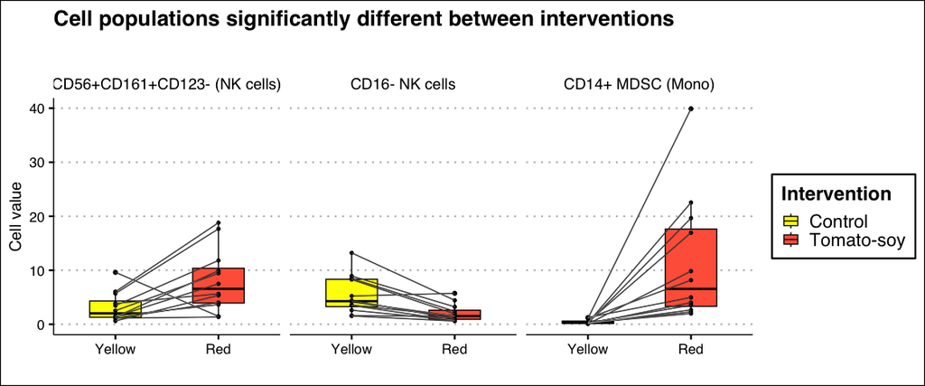

```r
meta_cells_long %>%
  filter(cell_type %in% sig_cells_intervention$cell_type) %>%
  filter(intervention != "Baseline") %>%
  filter(pre_post == "post") %>%
  ggpaired(x = "intervention", y = "cell_value", fill = "intervention", facet.by = "cell_type", short.panel.labs = FALSE, panel.labs = list(cell_type = c("CD56+CD161+CD123- (NK cells)", "CD16- NK cells", "CD14+ MDSC (Mono)"))) +
  scale_fill_manual(values = c("Yellow" = "yellow1",
                               "Red" = "tomato1"),
                    labels = c("Control", "Tomato-soy"),
                    name = "Intervention") +
  geom_line(aes(group = patient_id), colour = "gray", size = 0.15) +
  theme_clean(base_size = 18, base_family = "sans") +
  labs(x = "",
       y = "Cell value",
       title = "Cell populations significantly different between interventions",
       subtitle = "")
```

Let’s run a log2 transformation to get a better visual for CD14+ monocytes

```r
meta_log_cells_long <- meta_cells_long %>%
  mutate(log2_cell_value = log2(cell_value))
```

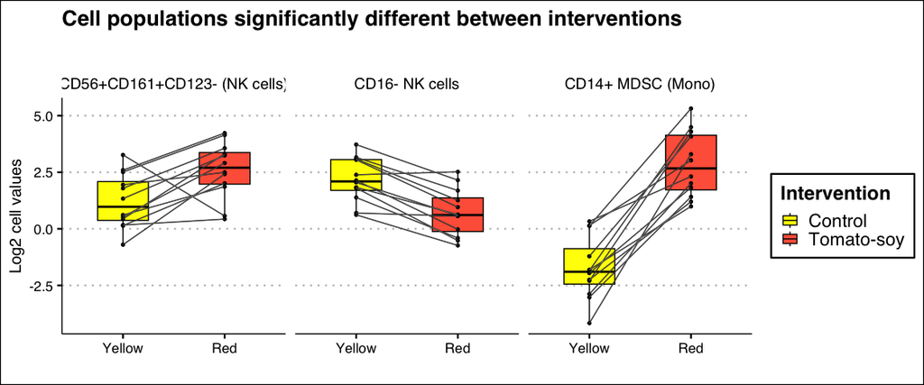

```r
meta_log_cells_long %>%
  filter(cell_type %in% sig_cells_intervention$cell_type) %>%
  filter(intervention != "Baseline") %>%
  filter(pre_post == "post") %>%
  ggpaired(x = "intervention", y = "log2_cell_value", fill = "intervention", facet.by = "cell_type", short.panel.labs = FALSE, panel.labs = list(cell_type = c("CD56+CD161+CD123- (NK cells)", "CD16- NK cells", "CD14+ MDSC (Mono)"))) +
  scale_fill_manual(values = c("Red" = "tomato1",
                               "Yellow" = "yellow1"),
                    labels = c("Control", "Tomato-soy"),
                    name = "Intervention") +
  geom_line(aes(group = patient_id), colour = "gray", size = 0.15) +
  theme_clean(base_size = 18, base_family = "sans") +
  labs(x = "",
       y = "Log2 cell values",
       title = "Cell populations significantly different between interventions",
       subtitle = "")
```

- Seems like the trend is CD56+CD161+ NK cells and CD14+ MDSCs are greater post-tomato soy compared to yellow interventions but the opposite for CD16- NK cells.

#### fold change

What is the avg fold change in the red intervention?

```r
intervention_cells_subset <- meta_cells_long %>%
  filter(intervention != "Baseline") %>%
  filter(cell_type %in% sig_cells_intervention$cell_type)%>%
  select(patient_id, pre_post_intervention, cell_type, cell_value) %>%
  group_by(cell_type) %>%
  pivot_wider(names_from = pre_post_intervention,
              values_from = cell_value) %>%
  mutate(post_intervention_FC = post_Red/post_Yellow)

intervention_cells_subset %>%
  summarize(mean_intervention_FC = mean(post_intervention_FC))
```

```
## # A tibble: 3 × 2
##   cell_type                     mean_intervention_FC
##   <chr>                                        <dbl>
## 1 x37_cd56_cd161_cd123_nk_cells                3.62
## 2 x38_cd16_nk_cells                            0.427
## 3 x40_cd14_mdsc_mono                          43.7
```

- CD14+ MDSC monocytes shows a huge mean fold change between interventions!